# The Verification Frontier

Where (if anywhere) can we measure critical AI literacy?

Derek C. Briggs — SSM 2026 (working simulation)

2026-06-19

> **How to read this document.** It is deliberately built to be *audited*, not trusted. Critical AI literacy is the ability to catch a plausible-but-wrong artifact you cannot verify at a glance — which is exactly the position you are in reading machine-generated code. So every modeling decision below is tagged **[CHOICE]**, and Sections 4.2–4.3 *check the math empirically* so you are not relying on my algebra being correct. If a claim is load-bearing, it is stated as something you can falsify.

# 1 The question

An LLM held at a fixed prompt has its variability set by a dial (temperature); across the handful of frontier models that variability is being engineered toward zero. So the durable human variance is not in the model. We conjecture it lives in **critical AI literacy** (`theta`): the capacity to detect and repair an output that is wrong but *plausible*.

This document asks a measurement question, not a philosophical one:

> Given a model with capability `c` and “seductiveness” `s`, **how much information does a single task carry about a person’s `theta`?** Equivalently: how many tasks would we need to measure `theta` reliably, and does that number grow or shrink as models improve?

# 2 The measurement model

One task = one Bernoulli outcome: *did the final answer come out correct after the human–AI interaction?* We model the success probability for a person with critical literacy `theta` as

$$P(\text{success}\mid\theta) \;=\; \underbrace{c}_{\text{AI right
unaided}}
\;+\;(1-c)\,\underbrace{g(\theta)}_{\text{user catches \& fixes a
wrong answer}}.$$

The two terms are the only two ways the final answer succeeds: either the AI was right on its own (probability `c`), or it fell short (probability `1-c`) and the user **over-rode** it.

**What “catch” means across domains.** In a *cheaply verifiable* domain (code, math) “catching” is literal error-detection against an objective check. In a domain where verification is *expensive or deferred* (the dinner-party story) there is no such check at hand, so “catch” means **appraisal**: correctly judging that a fluent, joke-shaped output will actually fall flat for the audience, and not being captured by its polish. The criterion is then a *deferred, social* verdict (does the room laugh?) rather than a unit test. So read `g(theta)` as **the probability the user correctly over-rides a plausible-but-inadequate answer** — by detection where a check is cheap, by appraisal where it is not.

The catch-and-repair probability is a standard 2-parameter logistic (IRT) item:

$$g(\theta) \;=\; \mathrm{logistic}\!\big(a\,(\theta - \delta(s))\big),
\qquad \mathrm{logistic}(x)=\frac{1}{1+e^{-x}} .$$

- **`theta`** — the person’s critical literacy. **[CHOICE]** population distribution `theta ~ N(0,1)`.
- **`a`** — discrimination of the catch process. **[CHOICE]** `a = 1.5`.
- **`delta(s)`** — *difficulty of over-riding* a plausible-but-inadequate answer, driven by model **seductiveness** `s`: how strongly surface fluency masks the (possibly deferred) verdict. More fluent duds are harder to over-ride, so `delta` increases in `s`. **[CHOICE]** linear map `s in [0,1] -> delta in [-3, 3]`.
- **`c`** — model **capability**, the probability the AI is right with no human intervention.

> **[CHOICE that you should attack]** Here `theta` is operationalized *narrowly* as the ability to over-ride a plausible-but-inadequate answer — error-detection where verification is cheap, appraisal where it is not. Your blog series frames critical AI literacy more broadly (calibrated trust, knowing *when* to invoke AI, interrogating framing). This model captures one facet. Decide whether that facet is the right stand-in for the talk, or whether the construct needs additional items of a different kind.

```r
A_DISC <- 1.5                 # [CHOICE] discrimination of the catch process
DELTA_MIN <- -3; DELTA_MAX <- 3   # [CHOICE] seductiveness -> catch-difficulty

logistic <- function(x) 1 / (1 + exp(-x))

# seductiveness s -> difficulty of catching a wrong answer
delta_of_s <- function(s) DELTA_MIN + (DELTA_MAX - DELTA_MIN) * s

# P(final answer correct | theta, c, s)
P_success <- function(theta, c, s) {
  g <- logistic(A_DISC * (theta - delta_of_s(s)))
  c + (1 - c) * g
}
```

## 2.1 Reading the parameters: an item characteristic curve

Plotting `P(success | theta)` against `theta` for a single item makes `c` and `delta(s)` concrete. `c` is the **floor** — the success rate of a person with no critical literacy, which rises with model capability. `delta(s)` is the **location**: the critical-literacy level at which success is halfway between the floor and 1. A more seductive item (higher `s`) has a larger `delta(s)` and shifts the curve **right** — harder to over-ride.

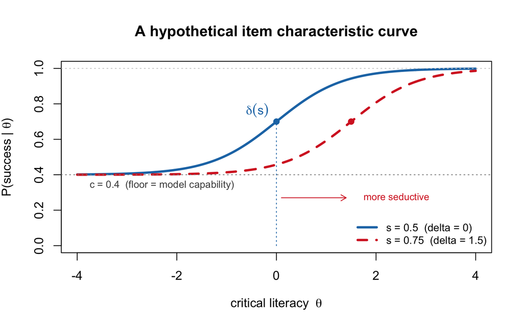

```r
th <- seq(-4, 4, length.out = 300)
cc <- 0.40                          # lower asymptote (model capability)
s1 <- 0.50; s2 <- 0.75              # two seductiveness levels
d1 <- delta_of_s(s1); d2 <- delta_of_s(s2)   # -> delta = 0 and 1.5
mid <- (cc + 1) / 2                 # halfway between floor and ceiling

plot(th, P_success(th, cc, s1), type = "l", lwd = 3, col = "#1f77b4", ylim = c(0, 1),
     xlab = expression(paste("critical literacy  ", theta)),
     ylab = expression(paste("P(success | ", theta, ")")),
     main = "A hypothetical item characteristic curve")
lines(th, P_success(th, cc, s2), lwd = 3, lty = 2, col = "#d62728")

abline(h = cc, col = "gray55", lty = 3); abline(h = 1, col = "gray80", lty = 3)
text(-3.9, cc - 0.06, paste0("c = ", cc, "  (floor = model capability)"),
     pos = 4, cex = 0.8, col = "gray30")

# delta(s) = theta where the curve passes the halfway point
segments(d1, 0, d1, mid, col = "#1f77b4", lty = 3)
points(d1, mid, pch = 19, col = "#1f77b4"); points(d2, mid, pch = 19, col = "#d62728")
text(d1, mid + 0.05, expression(delta(s)), col = "#1f77b4", pos = 2, cex = 1.0)
arrows(d1 + 0.1, 0.27, d2 - 0.1, 0.27, length = 0.08, col = "#d62728")
text(d2 + 0.1, 0.27, "more seductive", col = "#d62728", pos = 4, cex = 0.78)

legend("bottomright", bty = "n", cex = 0.85, lwd = 3, lty = c(1, 2),
       col = c("#1f77b4", "#d62728"),
       legend = c(paste0("s = ", s1, "  (delta = ", d1, ")"),
                  paste0("s = ", s2, "  (delta = ", d2, ")")))
```

## 2.2 Two domains: where capability can and cannot rise

The single most important refinement: **`c` does not mean the same thing in every domain.** The axis that matters is not a clean verifiable/unverifiable binary but the **cost and latency of verification** — how cheaply, quickly, and objectively the quality of an output can be checked. Write `v in [0,1]` for the *cheapness of verification*:

- **Cheaply verifiable** (`v = 1`: code compiles, the theorem checks, the arithmetic ties out). An objective signal is available at once, so training can push capability close to 1. As `c -> ~0.96` the opportunity term `(1-c) -> 0`, and by Check 3 the information about `theta` collapses. Critical literacy decays to “did you bother to run the test.”
- **Expensively / deferredly verifiable** (`v = 0`: is this joke funny for *my* dinner party? is this framing wise? is this prose any good?). A verifier still exists — the room laughs or it doesn’t — but it is **deferred, noisy, and audience-specific**. Two consequences: (i) training cannot cleanly optimize against so sparse and after-the-fact a signal, so capability **plateaus below 1** at `c_cap` — the model floor-raises *fluency*, not *quality*; and (ii) that same deferred verdict is the only scoring key for the human’s judgment, so critical literacy here is **appraisal** (seeing past fluency to anticipate the verdict) and remains the main thing between the user and a confident, plausible dud.

(*Genuinely* unverifiable output — pure preference with no convergent verdict even in principle — would have no scoring key at all, so critical literacy there would be **unmeasurable**, not merely expensive to measure. The interesting, measurable zone is real-quality-but-expensively-verified.)

We trace one model-progress path per domain. Generation `g in [0,1]` runs early -> frontier. Capability rises to a domain-dependent ceiling; seductiveness rises with fluency, **shared** across domains (a deliberate simplification — see caveats). The two roads start at the *same* early model and fork only because cheaply-verifiable capability can keep climbing while expensively-verifiable capability cannot.

```r
C0     <- 0.50   # [CHOICE] early capability, both domains
C_CEIL <- 0.96   # [CHOICE] verifiable capability ceiling (objective signal -> ~1)
C_CAP  <- 0.55   # [CHOICE] unverifiable capability ceiling (no signal -> plateau)
S0     <- 0.45   # [CHOICE] early seductiveness
S_MAX  <- 0.62   # [CHOICE] frontier seductiveness (fluency rises with scale)

cmax_of_v <- function(v) C_CAP + (C_CEIL - C_CAP) * v   # capability ceiling by domain
c_traj <- function(g, v) C0 + (cmax_of_v(v) - C0) * g   # capability over generations
s_traj <- function(g)    S0 + (S_MAX - S0) * g          # seductiveness over generations
```

# 3 Why this model encodes the thesis (claims to verify)

These are predictions you can check against the code, not assertions to accept:

1. **Capability erases the construct.** As `c -> 1`, `P -> 1` for *every* `theta`, so the curve flattens and information about `theta` must go to 0. A strong model on a checkable task leaves nothing to measure.
2. **A verification frontier exists.** For a population centered at `theta = 0`, a task is most informative when the catch-difficulty is matched to the population, `delta(s) ~ 0`, i.e. at an *intermediate* seductiveness. Too-easy errors (everyone catches) and too-hard errors (nobody catches) are both uninformative.

# 4 Fisher information: the per-task “measurement value”

For a single Bernoulli item with success probability `P(theta)`, the Fisher information a response carries about `theta` is

$$I(\theta) \;=\;
\frac{\big(P'(\theta)\big)^2}{P(\theta)\,\big(1-P(\theta)\big)},
\qquad P'(\theta)=\frac{dP}{d\theta}.$$

Differentiating our `P`:

$$P'(\theta) = (1-c)\,a\,g(\theta)\big(1-g(\theta)\big).$$

We report the **population-expected information** $\mathrm{E}_\theta[\,I(\theta)\,]$ over `theta ~ N(0,1)`: how much one task tells us about a randomly drawn person — i.e. the per-item value of the task as a measurement instrument.

```r
# grid quadrature for theta ~ N(0,1)
THETA <- seq(-4, 4, length.out = 401)
W <- dnorm(THETA); W <- W / sum(W)         # normalized N(0,1) weights

# analytic dP/dtheta
dP_dtheta <- function(theta, c, s) {
  g <- logistic(A_DISC * (theta - delta_of_s(s)))
  (1 - c) * A_DISC * g * (1 - g)
}

# Fisher information at a single theta
info_point <- function(theta, c, s) {
  P  <- P_success(theta, c, s)
  dP <- dP_dtheta(theta, c, s)
  denom <- pmax(P * (1 - P), 1e-9)
  dP^2 / denom
}

# population-expected information for one task
expected_information <- function(c, s) sum(W * info_point(THETA, c, s))
```

## 4.1 Check 1 — is `dP/dtheta` actually the derivative of `P`?

Before trusting the information formula, verify the analytic derivative against a finite-difference approximation. If my calculus is wrong, this fails loudly.

```r
set.seed(1)
eps <- 1e-6
ok <- TRUE
for (i in 1:200) {
  th <- runif(1, -3, 3); c <- runif(1, .1, .95); s <- runif(1, .05, .95)
  num <- (P_success(th + eps, c, s) - P_success(th - eps, c, s)) / (2 * eps)
  ana <- dP_dtheta(th, c, s)
  if (abs(num - ana) > 1e-5) ok <- FALSE
}
stopifnot(ok)
cat("PASS: analytic dP/dtheta matches finite differences.\n")
```

```
## PASS: analytic dP/dtheta matches finite differences.
```

## 4.2 Check 2 — is the Fisher-information *formula* right?

The Fisher information equals the variance of the score $\partial_\theta \log P(Y\mid\theta)$. For a Bernoulli outcome the score is $(Y-P)\,P' / [P(1-P)]$. We simulate outcomes at a fixed `theta` and confirm the empirical score variance matches `info_point()`.

```r
mc_information <- function(theta, c, s, n = 2e6) {
  P  <- P_success(theta, c, s)
  dP <- dP_dtheta(theta, c, s)
  Y  <- rbinom(n, 1, P)
  score <- (Y - P) * dP / (P * (1 - P))   # d/dtheta log-likelihood
  var(score)
}
set.seed(7)
for (case in list(c(0.3, 0.5, 0.4), c(0.6, 0.9, 0.55), c(-0.5, 0.7, 0.3))) {
  th <- case[1]; c <- case[2]; s <- case[3]
  cat(sprintf("theta=%+.1f c=%.2f s=%.2f  analytic=%.4f  monte-carlo=%.4f\n",
              th, c, s, info_point(th, c, s), mc_information(th, c, s)))
}
```

```
## theta=+0.3 c=0.50 s=0.40  analytic=0.1628  monte-carlo=0.1627
## theta=+0.6 c=0.90 s=0.55  analytic=0.0340  monte-carlo=0.0341
## theta=-0.5 c=0.70 s=0.30  analytic=0.1041  monte-carlo=0.1042
```

The Monte-Carlo column should track the analytic column to ~2 decimals. If it does, the per-task information function is trustworthy.

## 4.3 Check 3 — does information collapse as `c -> 1`? (Claim 1)

```r
sapply(c(0.3, 0.6, 0.9, 0.99, 0.999),
       function(c) expected_information(c, s = 0.5))
```

```
## [1] 0.2024030024 0.0957198694 0.0207277451 0.0019963680 0.0001989109
```

These should march monotonically toward 0 — confirming that a more capable model on a fixed task carries *less* information about critical literacy.

# 5 Panel A: where the trait is measurable

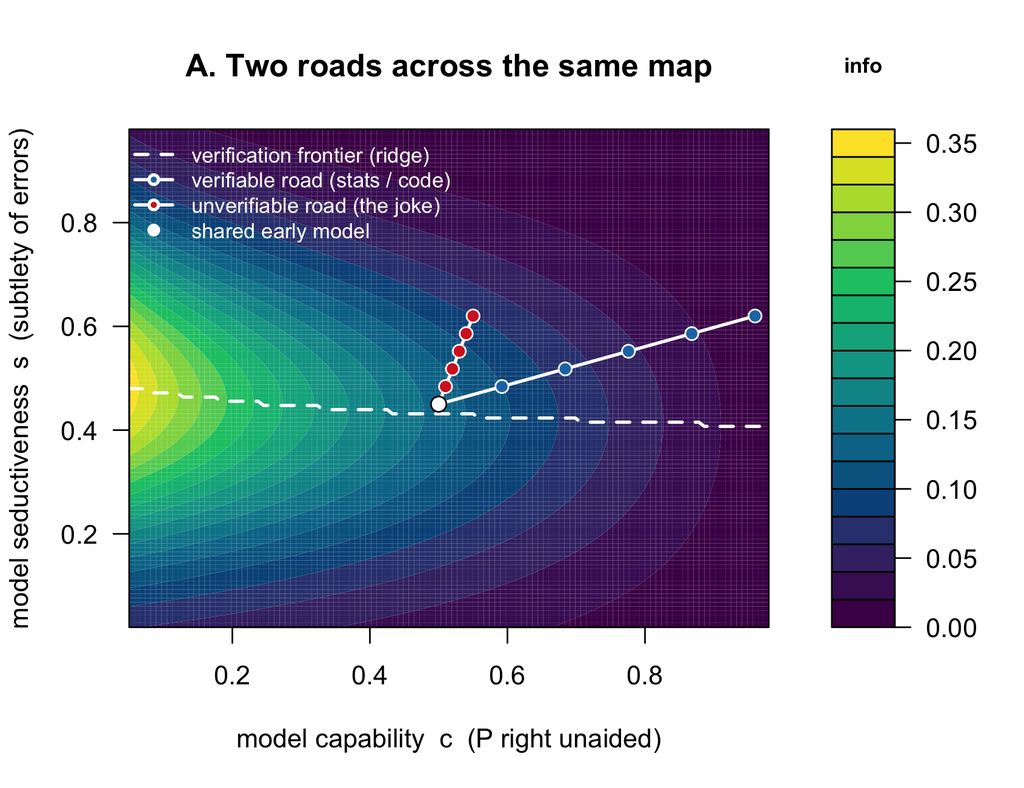

```r
cs <- seq(0.05, 0.98, length.out = 120)
ss <- seq(0.02, 0.98, length.out = 120)
INFO <- outer(cs, ss, Vectorize(expected_information))   # rows=c, cols=s

# verification-frontier ridge: best s for each c
ridge_s <- ss[apply(INFO, 1, which.max)]

# two roads across the same map, forked by verifiability
GEN <- seq(0, 1, length.out = 6)                 # early -> frontier
ver_c <- c_traj(GEN, 1); ver_s <- s_traj(GEN)    # verifiable domain (v=1)
unv_c <- c_traj(GEN, 0); unv_s <- s_traj(GEN)    # unverifiable domain (v=0)

filled.contour(
  x = cs, y = ss, z = INFO, color.palette = function(n) hcl.colors(n, "viridis"),
  xlab = "model capability  c  (P right unaided)",
  ylab = "model seductiveness  s  (subtlety of errors)",
  main = "A. Two roads across the same map",
  key.title = title(main = "info", cex.main = 0.8),
  plot.axes = {
    axis(1); axis(2)
    lines(cs, ridge_s, col = "white", lwd = 2, lty = 2)           # verification frontier
    lines(ver_c, ver_s, col = "white", lwd = 2)
    points(ver_c, ver_s, pch = 21, bg = "#1f77b4", col = "white", cex = 1.1)
    lines(unv_c, unv_s, col = "white", lwd = 2)
    points(unv_c, unv_s, pch = 21, bg = "#d62728", col = "white", cex = 1.1)
    # mark the shared start and the two frontiers (short, interior labels)
    points(ver_c[1], ver_s[1], pch = 21, bg = "white", col = "black", cex = 1.3)
    legend("topleft", bty = "n", text.col = "white", cex = 0.8,
           legend = c("verification frontier (ridge)",
                      "verifiable road (stats / code)",
                      "unverifiable road (the joke)",
                      "shared early model"),
           lty = c(2, 1, 1, NA), pch = c(NA, 21, 21, 21), lwd = c(2, 2, 2, NA),
           col = "white", pt.bg = c(NA, "#1f77b4", "#d62728", "white"))
  })
```

# 6 Panel B: the window narrows for verifiable tasks, not unverifiable ones

The info-vs-`s` curve is a function of `c` and `s` only — the surface is the same map for any domain. What `v` controls is *which* `c` a domain can reach. So we slice the map at the three capabilities the two roads actually occupy: the shared early model, the unverifiable frontier (`C_CAP`), and the verifiable frontier (`C_CEIL`).

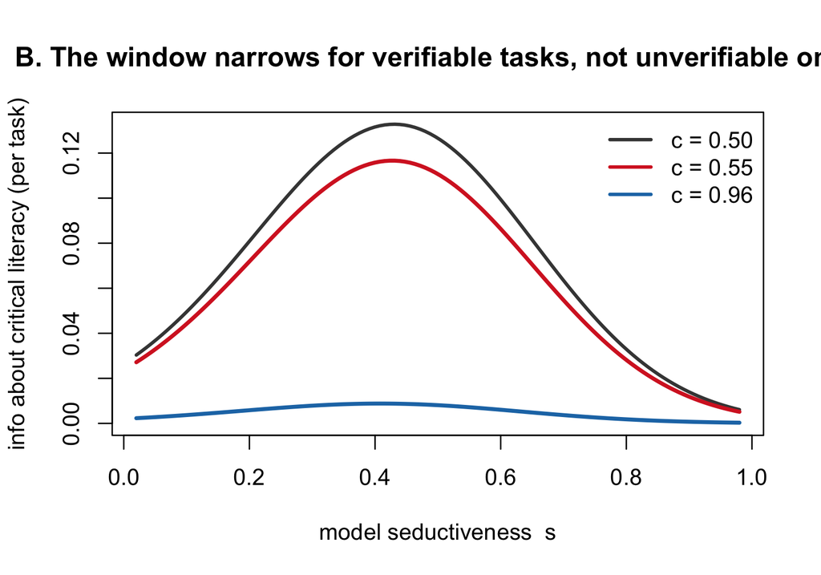

```r
infoB_early <- sapply(ss, function(s) expected_information(C0,     s))  # 0.50, both domains, early
infoB_unv   <- sapply(ss, function(s) expected_information(C_CAP,  s))  # 0.55, unverifiable frontier
infoB_ver   <- sapply(ss, function(s) expected_information(C_CEIL, s))  # 0.96, verifiable frontier

plot(ss, infoB_early, type = "l", lwd = 2.4, col = "#444444",
     ylim = c(0, max(infoB_early)),
     xlab = "model seductiveness  s",
     ylab = "info about critical literacy (per task)",
     main = "B. The window narrows for verifiable tasks, not unverifiable ones")
lines(ss, infoB_unv, lwd = 2.8, col = "#d62728")
lines(ss, infoB_ver, lwd = 2.8, col = "#1f77b4")
legend("topright", bty = "n", cex = 1.0, lwd = 2.4,
       legend = c("c = 0.50", "c = 0.55", "c = 0.96"),
       col = c("#444444", "#d62728", "#1f77b4"))
```

The unverifiable frontier (red) sits almost on top of the early model (grey): in deferredly-verified domains the measurement window barely narrows. Only the verifiable frontier (blue) collapses — the same `v`-contrast as Panel A, now sliced along `s`.

# 7 Panel C: is AI literacy a transient construct?

Translate information into a tangible cost. For a trait with variance 1, total information `I_tot` gives reliability `rho = I_tot / (I_tot + 1)`, so reaching `rho = 0.80` needs `I_tot = 4`. The number of trap-items required is `4 / E[info per item]`.

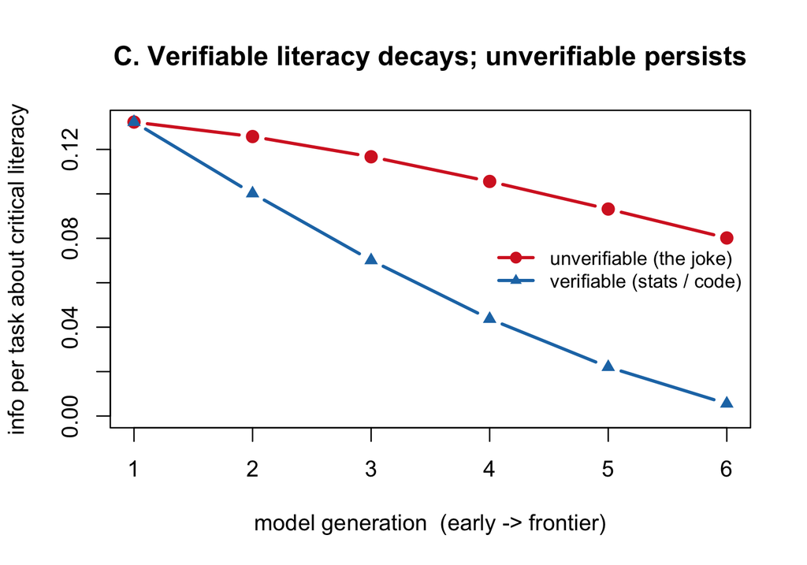

```r
RHO <- 0.80
I_NEED <- RHO / (1 - RHO)                     # = 4
items_for_reliability <- function(c, s) {
  e <- expected_information(c, s)
  if (e <= 1e-6) Inf else I_NEED / e
}

ver_info <- mapply(expected_information, ver_c, ver_s)   # verifiable road
unv_info <- mapply(expected_information, unv_c, unv_s)   # unverifiable road
gens <- seq_along(GEN)

plot(gens, unv_info, type = "b", pch = 19, col = "#d62728", lwd = 2.3,
     ylim = c(0, max(unv_info, ver_info)),
     xlab = "model generation  (early -> frontier)",
     ylab = "info per task about critical literacy",
     main = "C. Verifiable literacy decays; unverifiable persists")
lines(gens, ver_info, type = "b", pch = 17, col = "#1f77b4", lwd = 2.3)
legend("right", c("unverifiable (the joke)", "verifiable (stats / code)"),
       col = c("#d62728", "#1f77b4"), pch = c(19, 17), lwd = 2.3, bty = "n", cex = 0.85)
```

## 7.1 The headline table

```r
tab <- data.frame(
  point = c("shared early model", "verifiable frontier (stats/code)",
            "unverifiable frontier (the joke)"),
  c = c(ver_c[1], ver_c[6], unv_c[6]),
  s = c(ver_s[1], ver_s[6], unv_s[6]),
  info_per_item = c(expected_information(ver_c[1], ver_s[1]),
                    expected_information(ver_c[6], ver_s[6]),
                    expected_information(unv_c[6], unv_s[6])),
  items_for_rho_.80 = c(items_for_reliability(ver_c[1], ver_s[1]),
                        items_for_reliability(ver_c[6], ver_s[6]),
                        items_for_reliability(unv_c[6], unv_s[6]))
)
knitr::kable(tab, digits = c(0, 2, 2, 4, 0))
```

| point | c | s | info_per_item | items_for_rho_.80 |
| --- | --- | --- | --- | --- |
| shared early model | 0.50 | 0.45 | 0.1323 | 30 |
| verifiable frontier (stats/code) | 0.96 | 0.62 | 0.0056 | 719 |
| unverifiable frontier (the joke) | 0.55 | 0.62 | 0.0801 | 50 |

```r
prog <- data.frame(generation = gens,
                   ver_c = ver_c, ver_info = ver_info,
                   unv_c = unv_c, unv_info = unv_info,
                   ver_items = round(mapply(items_for_reliability, ver_c, ver_s)),
                   unv_items = round(mapply(items_for_reliability, unv_c, unv_s)))
knitr::kable(prog, digits = c(0, 2, 4, 2, 4, 0, 0))
```

| generation | ver_c | ver_info | unv_c | unv_info | ver_items | unv_items |
| --- | --- | --- | --- | --- | --- | --- |
| 1 | 0.50 | 0.1323 | 0.50 | 0.1323 | 30 | 30 |
| 2 | 0.59 | 0.1002 | 0.51 | 0.1258 | 40 | 32 |
| 3 | 0.68 | 0.0701 | 0.52 | 0.1167 | 57 | 34 |
| 4 | 0.78 | 0.0437 | 0.53 | 0.1056 | 92 | 38 |
| 5 | 0.87 | 0.0220 | 0.54 | 0.0932 | 181 | 43 |
| 6 | 0.96 | 0.0056 | 0.55 | 0.0801 | 719 | 50 |

# 8 An item-bank version: seductiveness vs. item difficulty

The model so far uses a *single* over-ride difficulty per generation, `delta_of_s(s)` — a one-item caricature. A real design has a **bank** of prompts whose errors vary in how seductive they are. So we **promote `delta_of_s(s)` from “the difficulty” to the *mean* of an item-difficulty distribution**, and draw a bank around it:

$$\delta_i \sim \mathrm{N}\big(\delta(s),\; \sigma_\delta\big),
\qquad i = 1, \dots, N_\mathrm{items} .$$

Capability `c` stays fixed per generation (your call this round). A key consequence: because seductiveness `s` is shared across the two domains, **they draw from the *same* difficulty bank** and differ only in the model that scores it (`c = C_CAP` vs `c = C_CEIL`).

```r
SIGMA_DELTA <- 1.0     # [CHOICE] spread of item difficulties (logits) around the mean
N_ITEMS     <- 200     # [CHOICE] prompts in the bank
BANK_SEED   <- 2026

# per-item info as a function of difficulty delta DIRECTLY (theta ~ N(0,1))
info_point_delta <- function(theta, c, delta) {
  g  <- logistic(A_DISC * (theta - delta))
  P  <- c + (1 - c) * g
  dP <- (1 - c) * A_DISC * g * (1 - g)
  dP^2 / pmax(P * (1 - P), 1e-9)
}
ei_delta <- function(c, delta) sum(W * info_point_delta(THETA, c, delta))

# consistency: the representative-item model is just the single-item case
stopifnot(abs(ei_delta(0.55, delta_of_s(0.62)) -
              expected_information(0.55, 0.62)) < 1e-9)
cat("PASS: ei_delta reproduces the representative-item information.\n")
```

```
## PASS: ei_delta reproduces the representative-item information.
```

```r
# exact bank expectation: average per-item info over delta ~ N(delta_of_s(s), sigma)
DELTA_GRID <- seq(-7, 7, length.out = 281)
bank_info_exact <- function(c, s, sigma = SIGMA_DELTA) {
  wd <- dnorm(DELTA_GRID, delta_of_s(s), sigma); wd <- wd / sum(wd)
  sum(wd * sapply(DELTA_GRID, function(d) ei_delta(c, d)))
}

# a concrete RANDOM bank of N_ITEMS prompts
draw_bank <- function(c, s, sigma = SIGMA_DELTA, n = N_ITEMS, seed = NULL) {
  if (!is.null(seed)) set.seed(seed)
  delta_i <- rnorm(n, delta_of_s(s), sigma)
  list(delta = delta_i,
       info  = sapply(delta_i, function(d) ei_delta(c, d)))
}
```

## 8.1 Same bank, two capabilities

The same trap-items are highly informative scored through a weak model and nearly useless scored through a strong one — the divergence is entirely in the lower asymptote, not the difficulties.

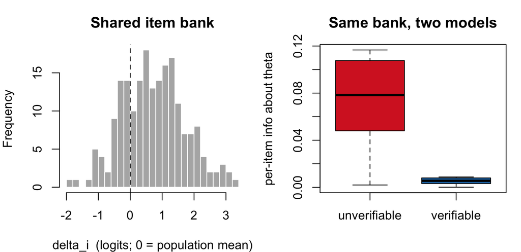

```r
s_front <- S_MAX                              # shared frontier seductiveness (= 0.62)
set.seed(BANK_SEED)
delta_i  <- rnorm(N_ITEMS, delta_of_s(s_front), SIGMA_DELTA)
info_unv <- sapply(delta_i, function(d) ei_delta(C_CAP,  d))   # c = 0.55 (unverifiable)
info_ver <- sapply(delta_i, function(d) ei_delta(C_CEIL, d))   # c = 0.96 (verifiable)

par(mfrow = c(1, 2), mar = c(4, 4, 3, 1))
hist(delta_i, breaks = 20, col = "gray70", border = "white",
     main = "Shared item bank", xlab = "delta_i  (logits; 0 = population mean)")
abline(v = 0, lty = 2)
boxplot(list(unverifiable = info_unv, verifiable = info_ver),
        col = c("#d62728", "#1f77b4"), ylab = "per-item info about theta",
        main = "Same bank, two models")
```

```r
par(mfrow = c(1, 1))

cat(sprintf("random bank  : unverifiable mean=%.4f (items=%.0f) | verifiable mean=%.4f (items=%.0f)\n",
            mean(info_unv), 4/mean(info_unv), mean(info_ver), 4/mean(info_ver)))
```

```
## random bank  : unverifiable mean=0.0739 (items=54) | verifiable mean=0.0053 (items=757)
```

```r
cat(sprintf("exact bank   : unverifiable     =%.4f             | verifiable     =%.4f\n",
            bank_info_exact(C_CAP, s_front), bank_info_exact(C_CEIL, s_front)))
```

```
## exact bank   : unverifiable     =0.0734             | verifiable     =0.0052
```

## 8.2 The divergence survives a real bank

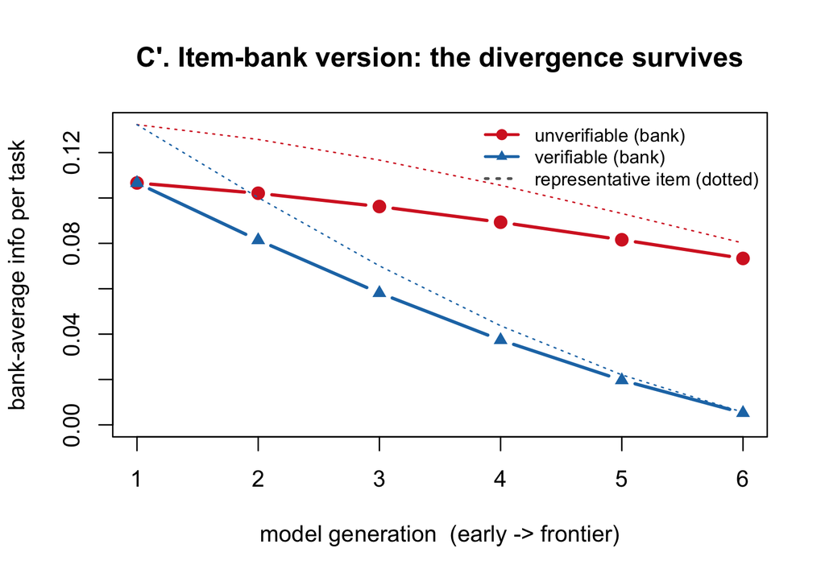

```r
ver_info_bank <- sapply(seq_along(GEN), function(i) bank_info_exact(ver_c[i], ver_s[i]))
unv_info_bank <- sapply(seq_along(GEN), function(i) bank_info_exact(unv_c[i], unv_s[i]))

plot(gens, unv_info_bank, type = "b", pch = 19, col = "#d62728", lwd = 2.3,
     ylim = c(0, max(unv_info_bank, unv_info)),
     xlab = "model generation  (early -> frontier)",
     ylab = "bank-average info per task",
     main = "C'. Item-bank version: the divergence survives")
lines(gens, ver_info_bank, type = "b", pch = 17, col = "#1f77b4", lwd = 2.3)
lines(gens, unv_info, lty = 3, col = "#d62728")     # representative-item, for comparison
lines(gens, ver_info, lty = 3, col = "#1f77b4")
legend("topright", bty = "n", cex = 0.8,
       legend = c("unverifiable (bank)", "verifiable (bank)", "representative item (dotted)"),
       col = c("#d62728", "#1f77b4", "gray40"), pch = c(19, 17, NA),
       lty = c(1, 1, 3), lwd = 2)
```

Bank-average information is **lower** than the representative-item value (the bank includes off-target prompts), so items-needed rises modestly — the joke goes from ~50 to ~55, the verifiable frontier from ~719 to ~769 — but the verifiable-vs-unverifiable gap is unchanged.

## 8.3 Sampling variability of a random bank

Because the bank is drawn at random, the items-needed estimate has its own uncertainty. This is honest measurement bookkeeping — and a reminder that “50 items” is itself an estimate.

```r
set.seed(BANK_SEED)
reps <- replicate(300, {
  d <- rnorm(N_ITEMS, delta_of_s(s_front), SIGMA_DELTA)
  4 / mean(sapply(d, function(x) ei_delta(C_CAP, x)))
})
cat(sprintf("Unverifiable frontier, items-needed across 300 random banks of %d prompts:\n  median=%.0f   90%% interval [%.0f, %.0f]\n",
            N_ITEMS, median(reps), quantile(reps, .05), quantile(reps, .95)))
```

```
## Unverifiable frontier, items-needed across 300 random banks of 200 prompts:
##   median=54   90% interval [52, 58]
```

Wider `SIGMA_DELTA` scatters prompts further from the informative region, lowering average information and raising items-needed: that is the design lever for *how tightly the prompt bank should target the population.* The “moving frontier” becomes concrete here — as `s` drifts up across generations, you must re-center `delta_of_s(s)` and re-cover the population, or the bank decays.

# 9 Honest caveats (the places to push)

```r
# Re-run the whole story under your own assumptions.
# NOTE: this temporarily sets the global parameters, then RESTORES them on exit,
# so calling it leaves no side effects (an earlier version leaked global state --
# see the lesson in the prose above).
sensitivity <- function(a = 1.5, dmin = -3, dmax = 3, rho = 0.80) {
  old <- list(A_DISC, DELTA_MIN, DELTA_MAX)
  on.exit({ A_DISC <<- old[[1]]; DELTA_MIN <<- old[[2]]; DELTA_MAX <<- old[[3]] })
  A_DISC <<- a; DELTA_MIN <<- dmin; DELTA_MAX <<- dmax
  data.frame(
    verifiable_frontier = (rho/(1-rho)) / expected_information(0.96, 0.62),
    unverifiable_frontier = (rho/(1-rho)) / expected_information(0.55, 0.62),
    shared_early = (rho/(1-rho)) / expected_information(0.50, 0.45)
  )
}
sensitivity()                       # defaults (delta -3..3, a=1.5)
```

[output not shown]

```
##   verifiable_frontier unverifiable_frontier shared_early
## 1            718.5055              49.90846     30.22994
```

```r
sensitivity(a = 1.0)                # less discriminating catch process
```

```
##   verifiable_frontier unverifiable_frontier shared_early
## 1            1304.687              89.34727     57.11708
```

```r
sensitivity(dmin = -2, dmax = 2)    # narrower seductiveness range
```

```
##   verifiable_frontier unverifiable_frontier shared_early
## 1            613.6437              43.35545     30.50849
```

# 10 What to take to the talk

- **Two roads, one map.** The same model progress that drives critical literacy *off* the measurable ridge in verifiable domains (code/stats) keeps it *on* the ridge in unverifiable ones (the joke) — because capability can climb toward 1 only where there is a ground-truth signal to climb. See the headline table for the trap-items each road needs.
- **The construct is most measurable exactly where the model can help least.** Critical AI literacy is durable in domains where the AI cannot verify itself — judgment, taste, framing, wisdom — which is both why it matters and why it is hard to certify.
- **A live empirical question, not a settled one.** Whether unverifiable-domain literacy truly persists, or eventually erodes as fluency outruns human detection (`s` past the catchable band), is the design that a future study would test. That is Chollet’s generalization frontier relocated onto the human.